# Assignment1

GCuevas

Thursday, January 15, 2015

# Peer Assessment 1

## Loading and preprocessing the data

The database is stored in the link provided, https://d396qusza40orc.cloudfront.net/repdata%2Fdata%2Factivity.zip, which is a zip file with a csv file inside. Thus, downloading the file is a 3-step process: download it, unzip it and read it:

#### Downloading the file

```r
temp <- tempfile()
download.file("https://d396qusza40orc.cloudfront.net/repdata%2Fdata%2Factivity.zip", temp)
```

#### Unzipping and unlinking

```r
file<-unzip(temp)
unlink(temp)
```

#### Reading data, formatting the date and loading the data for it to Knit

```r
raw_data <- read.csv(file, header = TRUE, na.strings = "NA")
as.Date(raw_data$date, format = "%Y-%m-%d")
```

```r
load(file = "raw_data.RData")
```

## What is mean total number of steps taken per day?

For this part of the assignment we first create a histogram of the total number of steps taken each day. First, the total number of steps per day is calculated as `tapply(raw_data$steps, raw_data$date, sum)`. Then the histogram is created using the preset number of class intervals. The histogram is formatted for it to have red columns and correct and intuitive labels.

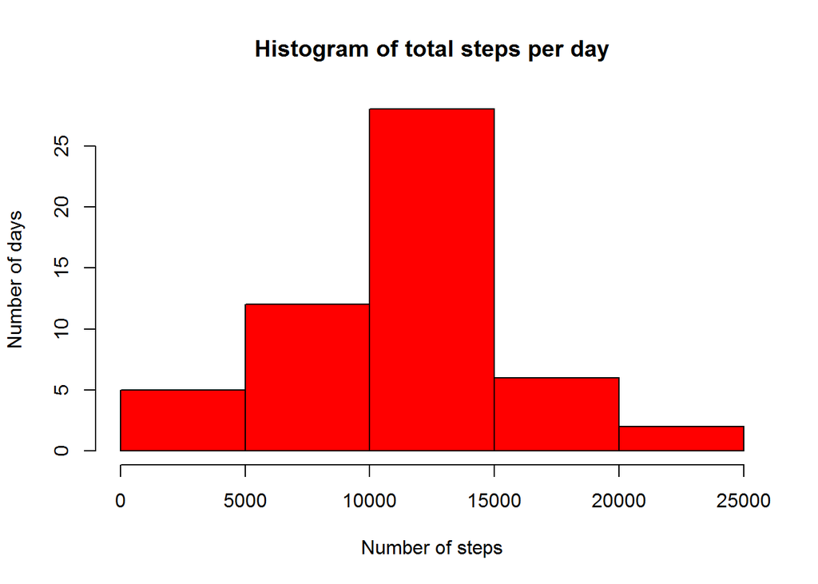

```r
hist(tapply(raw_data$steps, raw_data$date, sum), col = "red", main = "Histogram of total steps per day", xlab = "Number of steps", ylab = "Number of days")
```

If we look at the data, we can see that there are several `NA` in the $steps$ variable.

```r
head(raw_data)
```

```
##   steps       date interval            datetime
## 1    NA 2012-10-01        0 2012-10-01 00:00:00
## 2    NA 2012-10-01        5 2012-10-01 00:05:00
## 3    NA 2012-10-01       10 2012-10-01 00:10:00
## 4    NA 2012-10-01       15 2012-10-01 00:15:00
## 5    NA 2012-10-01       20 2012-10-01 00:20:00
## 6    NA 2012-10-01       25 2012-10-01 00:25:00
```

```r
mean(tapply(raw_data$steps, raw_data$date, sum, na.rm = TRUE))
```

```
## [1] 9354.23
```

```r
median(tapply(raw_data$steps, raw_data$date, sum, na.rm = TRUE))
```

```
## [1] 10395
```

## What is the average daily activity pattern?

To see the average daily activity we need to calculate the mean per 5-minute interval. That is achieved using `tapply(raw_data$steps, raw_data$interval, mean, na.rm = TRUE)`. That function produces the mean number of steps per interval. Those numbers are use to build the **time series plot of the 5-minute interval and the average number of steps taken:**

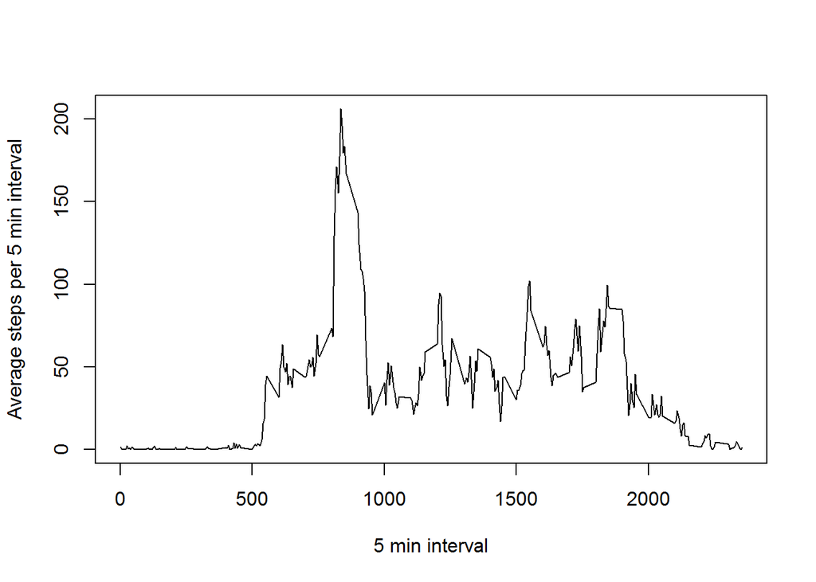

```r
plot(tapply(raw_data$interval, raw_data$interval, mean, na.rm = TRUE), tapply(raw_data$steps, raw_data$interval, mean, na.rm = TRUE), type = "l", ylab = "Average steps per 5 min interval", xlab = "5 min interval")
```

Notice that `tapply(raw_data$interval, raw_data$interval, mean, na.rm = TRUE)` was used as a trick to also obtain the intervals. To obtain the **5-minute interval that contains the maximum number of steps** we use the following sintax:

```r
which.max(tapply(raw_data$steps, raw_data$interval, mean, na.rm = TRUE))
```

```
## 835
## 104
```

Notice that `which` is a correct approach in this case because the plot clearly shows the existence of just one maximum value. In this case, we just found out that the interval **from 8:35 to 8:40 is the interval with the largest number of steps on average**.

## Inputing missing values

We have already noticed the existence of several missing values and have worked around that. Now we are trying to input those values. First, we calculate **the total number of missing values in the dataset:**

```r
summary(raw_data)
```

```
##      steps                date          interval
##  Min.   :  0.00   2012-10-01:  288   Min.   :   0.0
##  1st Qu.:  0.00   2012-10-02:  288   1st Qu.: 588.8
##  Median :  0.00   2012-10-03:  288   Median :1177.5
##  Mean   : 37.38   2012-10-04:  288   Mean   :1177.5
##  3rd Qu.: 12.00   2012-10-05:  288   3rd Qu.:1766.2
##  Max.   :806.00   2012-10-06:  288   Max.   :2355.0
##  NA's   :2304     (Other)   :15840
##     datetime
##  Min.   :2012-10-01 00:00:00
##  1st Qu.:2012-10-16 05:58:45
##  Median :2012-10-31 11:57:30
##  Mean   :2012-10-31 12:23:58
##  3rd Qu.:2012-11-15 17:56:15
##  Max.   :2012-11-30 23:55:00
##
```

As the summary shows, **there are 2,304 missing values**.

We now **fill in all of the missing values as the mean for the corresponding 5-minute intevals**. We do so by using a *for* loop (I tried to use one of the apply functions but could not make it work). The **new dataset that is equal to the original dataset but with the missing data filled in is named *compdata*** :

```r
compdata <- raw_data
for(i in 1:17568){
  if(is.na(compdata[i,1])){
    compdata[i,1] <- mean(compdata[which(compdata$interval == compdata$interval[i]),1], na.rm = TRUE)}}
```

The **histogram of the total number of steps for the new database** is now shown:

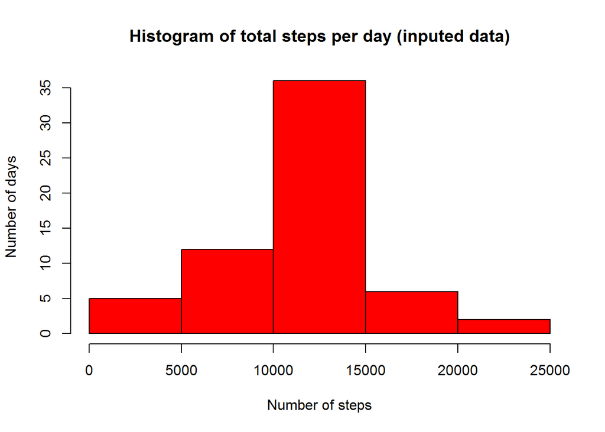

```r
hist(tapply(compdata$steps, compdata$date, sum), col = "red", main = "Histogram of total steps per day (inputed data)", xlab = "Number of steps", ylab = "Number of days")
```

The new histogram shows a dataset that is more skewed towards the centre. We confirm that intuitive result with **the mean and median of the total number of steps taken per day:**

```r
mean(tapply(compdata$steps, compdata$date, sum))
```

```
## [1] 10766.19
```

```r
median(tapply(compdata$steps, compdata$date, sum))
```

```
## [1] 10766.19
```

**The impact of imputing missing data on the estimates of the total daily number of steps** in the way we did it is that both the mean and the median are now larger than they were in the original dataset.

## Are there differences in activity patterns between weekdays and weekends?

To answer to that questions we need to **create a new factor variable in the dataset with two levels, “weekday” and “weekend”**. We do so by instaling the `timeDate` package and using its `isWeekday` function to create the *weekday* variable:

```r
install.packages("timeDate")
library("timeDate", lib.loc="C:/Program Files/R/R-3.1.1/library")
compdata$weekday <- isWeekday(compdata$date)
```

The *weekday* variable was created as a binary variable: it is `TRUE` if the date is a weekday and false otherwise.

Finally, we create the **Panel plot containing a time series plot average across all weekday days and weekend days**. We create those plots using the basic plot features and the format presented in the README file.

```r
par(mfrow = c(2,1), cex = 0.6)

print(plot(xlim = c(0, 2500), ylim = c(0,250), tapply(compdata$interval[which(compdata$weekday == FALSE)], compdata$interval[which(compdata$weekday == FALSE)], mean, na.rm = TRUE), tapply(compdata$steps[which(compdata$weekday == FALSE)], compdata$interval[which(compdata$weekday == FALSE)], mean, na.rm = TRUE), type = "l", lty = 1, ylab = "Average steps per 5 min interval", xlab = "5 min interval over weekends"))
```

[figure not shown]

```r
print(plot(xlim = c(0, 2500), ylim = c(0,250), tapply(compdata$interval[which(compdata$weekday == TRUE)], compdata$interval[which(compdata$weekday == TRUE)], mean, na.rm = TRUE), tapply(compdata$steps[which(compdata$weekday == TRUE)], compdata$interval[which(compdata$weekday == TRUE)], mean, na.rm = TRUE), type = "l", lty = 1, ylab = "Average steps per 5 min interval", xlab = "5 min interval over weekdays"))
```

**NOTE:** The above plots were supposed to be time series and when run in the console, they work fine. You can see the plot in the panelplot.png file. I don’t expect to get credit for it but just showing a problem I didn’t have time to solve.

*Thanks for visiting*